# MATH1318 Time Series Analysis - Assignment 1

Adam Pirsl S3815427

# 1 Introduction

The ozone layer is a generic term used to describe the high concentration of ozone that surrounds the earth. The ozone sits within the stratosphere at a height of 15-30 km above the earths crust. The ozone’s purpose is to absorb ultraviolet radiation from the sun that in turn makes life of earth habitable by humans and other living organisms.

Over the last 100 years, humans have contributed to the destruction of the ozone layer, largely through the release of chlorofluorocarbons that are found in aerosol cans and refrigerants. Studies carried out by United Nations Environmental Program indicate that current rates of ozone depletion is unprecedented in the last 600 years and that continual depletion of the ozone is contributing to global warming. This has led scientists to question the impacts and damage caused by future levels of ozone depletion.

# 2 Aims and objectives

Ozone thickness is measured in Dobson units and has been recorded on a yearly basis since 1927 to 2016. This analysis aims to build time series models that will forecast the future state of the ozone layer over the next 5 years from 2017 to 2021.

The data set will undergo a high level analysis of each time series characteristic to better understand how it should be handled. Multiple forecasting models will be built and assessed, including polynomial models and ARIMA models.

# 3 Methodology

## 3.1 Import libraries and load the data set

```r
# import libraries
library(readr)
library(dplyr)
library(tidyr)
library(magrittr)
library(TSA)
library(readxl)
library(zoo)
library(writexl)
library(tseries)
library(knitr)
library(latex2exp)
# opts_knit$set(eval.after = 'fig.cap')
# set wd
setwd("~/Documents/RMIT/TimeSeriesAnalysis/Assignment1")

# import data
ozone <- read_csv("data1.csv", col_names = FALSE)
```

## 3.2 Fundamental Analysis

The data first needs to be converted to a time series object. This is completed using the TSA package in R. The time series is object is plotted in Figure 3.1 below.

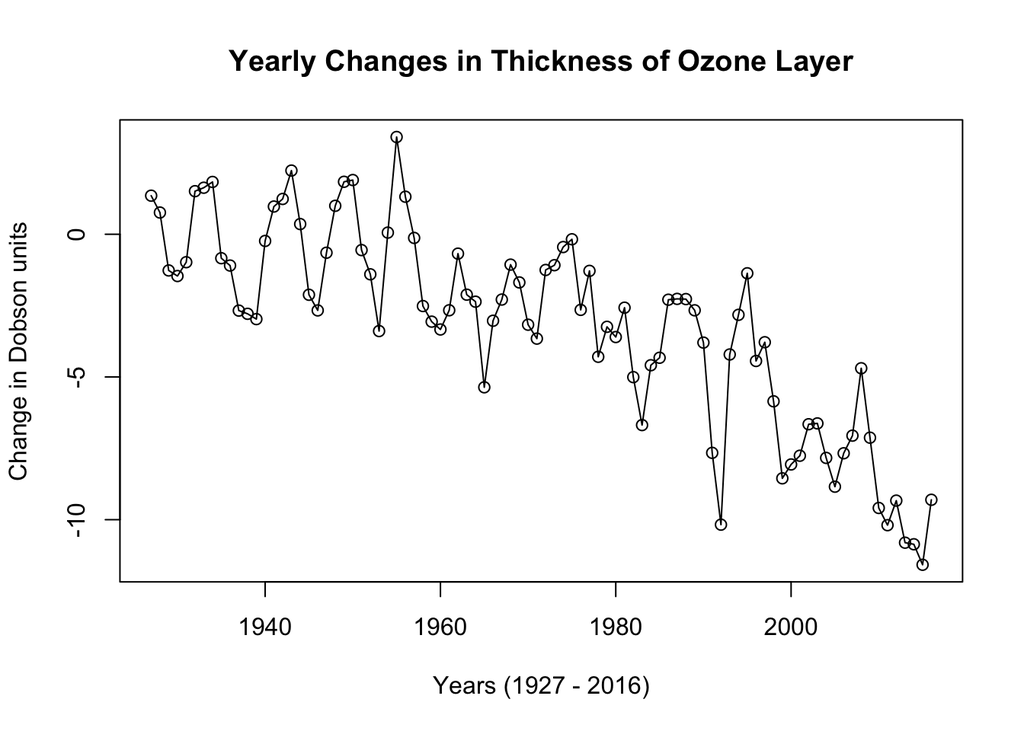

Figure 3.1: Ozone changes in Dobson units

```r
# convert to time series
ozone_1927_2016 <- ts(as.vector(ozone), start=1927, end=2016)

# plot the time series
plot(ozone_1927_2016,
     type='o',
     main ="Yearly Changes in Thickness of Ozone Layer",
     ylab = "Change in Dobson units",
     xlab = "Years (1927 - 2016)")
```

**Behavior:** There is both autoregressive (AR) and moving average (MA) characteristics withing the time series. There are multiple data points contributing to the upward and downward shift of the time series (AR) such as at approximately 1937 to 1940. There are also characteristics of random movement (MA), however it is not as dominant as the AR behaviour.

**Changing variance:** There are no obvious signs of changing variance.

**Trend:**There is a downward trend.

**Seasonality:** There is no distinct seasonality between equal sets of years.

**Change point:** There is a small change point at approximately 1995. This relatively extreme movement is out of proportion compared to other year on year movements.

## 3.3 Polynomial Regression

### 3.3.1 Linear Regression

```r
# Fit the linear model
t = time(ozone_1927_2016)
model1 = lm(ozone_1927_2016~t)
summary(model1)
```

```
##
## Call:
## lm(formula = ozone_1927_2016 ~ t)
##
## Residuals:
##     Min      1Q  Median      3Q     Max
## -4.7165 -1.6687  0.0275  1.4726  4.7940
##
## Coefficients:
##               Estimate Std. Error t value Pr(>|t|)
## (Intercept) 213.720155  16.257158   13.15   <2e-16 ***
## t            -0.110029   0.008245  -13.34   <2e-16 ***
## ---
## Signif. codes:  0 '***' 0.001 '**' 0.01 '*' 0.05 '.' 0.1 ' ' 1
##
## Residual standard error: 2.032 on 88 degrees of freedom
## Multiple R-squared:  0.6693, Adjusted R-squared:  0.6655
## F-statistic: 178.1 on 1 and 88 DF,  p-value: < 2.2e-16
```

```r
model1
```

```
##
## Call:
## lm(formula = ozone_1927_2016 ~ t)
##
## Coefficients:
## (Intercept)            t
##      213.72        -0.11
```

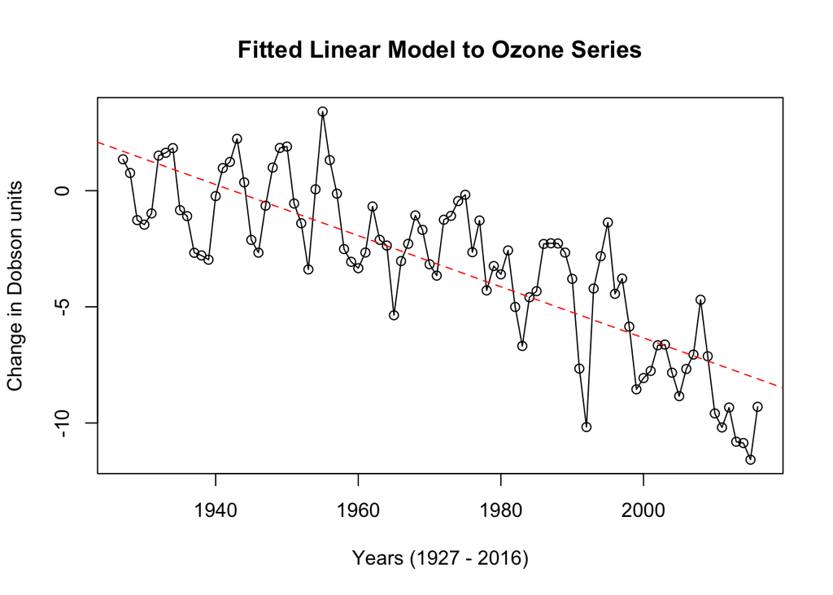

Figure 3.2: Fitted linear model

```r
# fit the linear model
plot(ozone_1927_2016,type='o',
     ylab='Change in Dobson units',
     main = "Fitted Linear Model to Ozone Series",
     xlab = "Years (1927 - 2016)")
abline(model1,type="l",lty=2,col="red")
```

### 3.3.2 Key Linear Model Statistics

1. R squared value is 0.6655, meaning that the model is not overly fitted and there is a some degree of variability in the dependent variable within the model.
2. P-value is less than 0.05 at < 2.2e-16, meaning the linear trend is statistically significant.

### 3.3.3 Residual Analysis

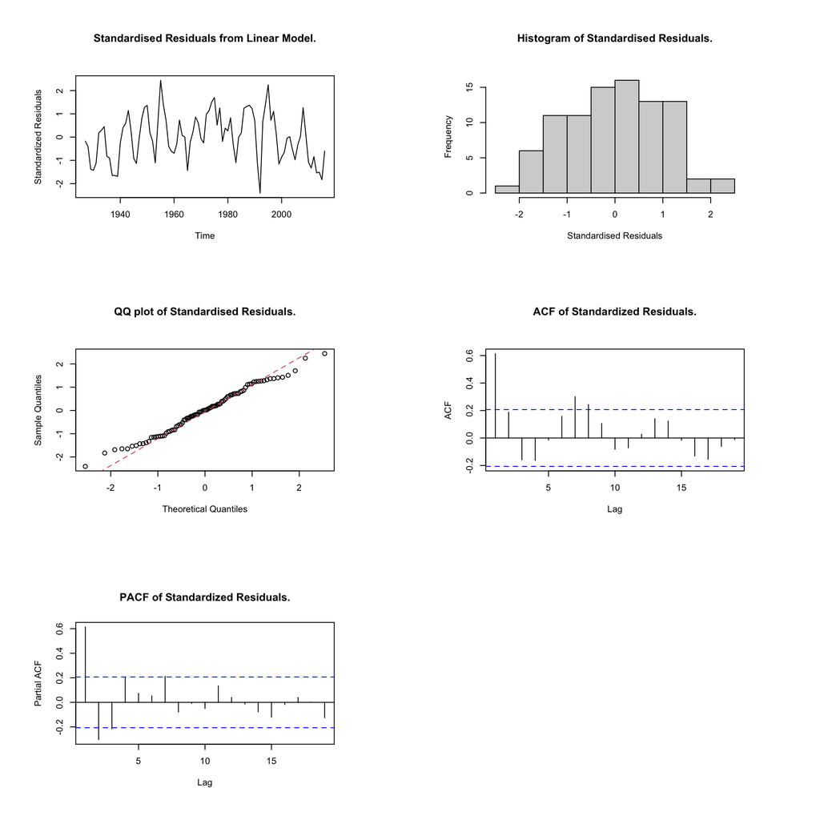

Figure 3.3: Residual analysis

```r
# Residual analysis
res.model1 = rstudent(model1)
par(mfrow=c(3,2),mar=c(7,7,7,7))

res.model1 = rstudent(model1)
plot(y = res.model1,
     x = as.vector(time(ozone_1927_2016)),
     xlab = 'Time',
     ylab='Standardized Residuals',type='l',
     main = "Standardised Residuals from Linear Model."
     )

hist(res.model1,
     xlab='Standardised Residuals',
     main = "Histogram of Standardised Residuals.")


qqnorm(y=res.model1,
       main = "QQ plot of Standardised Residuals.")

qqline(y=res.model1, col = 2, lwd = 1, lty = 2)

acf(res.model1, main = "ACF of Standardized Residuals.")

pacf(res.model1, main = "PACF of Standardized Residuals.")

par(mfrow=c(1,1))
```

```r
shapiro.test(res.model1)
```

```
##
##  Shapiro-Wilk normality test
##
## data:  res.model1
## W = 0.98733, p-value = 0.5372
```

**1. Standardised residuals**

There are no residuals that exceed 3 or -3 on the normal standardised residual graph. The movement does not appear to be random.

**2. Histogram of standardised residuals**

The histogram appears mostly uniform, although the left side is slopped more evenly compared to the right tail that drops of suddenly. Uniformity in the histogram suggests the model fits the linear trend.

**3. QQ Plot**

The straight line pattern along the reference line supports the hypothesis of a normally distributed stochastic component in this model. Higher departure from the reference line would mean the linear model does not fit the trend. At either end of the plot, the residuals peel off from the reference line, indicating there is some changing variance of the standardised residuals.

**4. ACF**

The ACF plot confirms there is auto correlation as there are correlation values higher than the confidence bounds at lag 1 as well as 2 which is slightly significant. This outcome would not be expected from a white noise process.

**5. PACF**

PACF is the correlation of the standardised residuals. It is intended to identify hidden information in the residual which can be modeled by the next lag. There is significant auto correlation of the standardised residuals at lags 1 and 2 as well as a slightly significant correlation at lag 3.

**6. Shapiro test**  
p-value = 0.5372

### 3.3.4 Quadratic Regression

```r
# Fit the quadratic model
t = time(ozone_1927_2016)
t2 = t^2
model2 = lm(ozone_1927_2016~ t + t2)
summary(model2)
```

```
##
## Call:
## lm(formula = ozone_1927_2016 ~ t + t2)
##
## Residuals:
##     Min      1Q  Median      3Q     Max
## -5.1062 -1.2846 -0.0055  1.3379  4.2325
##
## Coefficients:
##               Estimate Std. Error t value Pr(>|t|)
## (Intercept) -5.733e+03  1.232e+03  -4.654 1.16e-05 ***
## t            5.924e+00  1.250e+00   4.739 8.30e-06 ***
## t2          -1.530e-03  3.170e-04  -4.827 5.87e-06 ***
## ---
## Signif. codes:  0 '***' 0.001 '**' 0.01 '*' 0.05 '.' 0.1 ' ' 1
##
## Residual standard error: 1.815 on 87 degrees of freedom
## Multiple R-squared:  0.7391, Adjusted R-squared:  0.7331
## F-statistic: 123.3 on 2 and 87 DF,  p-value: < 2.2e-16
```

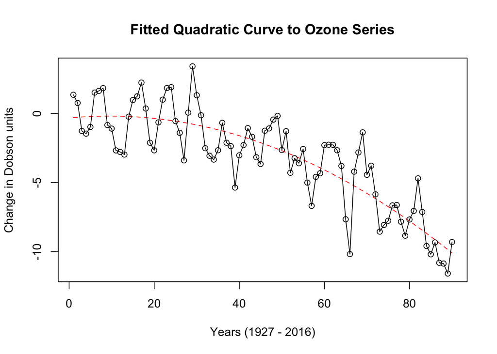

Figure 3.4: Fitted quadratic model

```r
plot(ts(fitted(model2)), ylim = c(min(c(fitted(model2), as.vector(ozone_1927_2016))), max(c(fitted(model2),as.vector(ozone_1927_2016)))),
     ylab='Change in Dobson units' ,
     xlab = "Years (1927 - 2016)",
     main = "Fitted Quadratic Curve to Ozone Series",
     type="l",lty=2,
     col="red")
lines(as.vector(ozone_1927_2016),type="o")
```

### 3.3.5 Key Quadratic Model Statistics

1. R squared value of 0.7331 indicates the model fits the time series without being overly fitted.
2. P-value statistic of < 2.2e-16 shows the model is statistically significant.

### 3.3.6 Residual Analysis

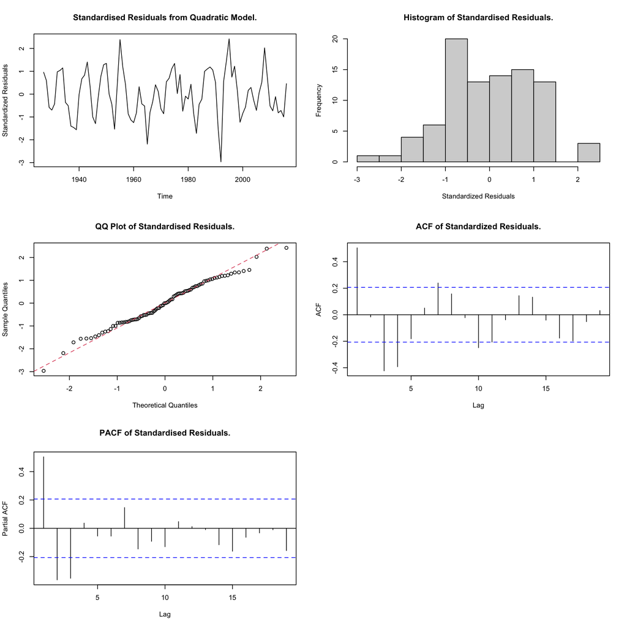

Figure 3.5: Quadratic Residual Analysis

```r
# Residual analysisÍ›
res.model2 = rstudent(model2)
par(mfrow=c(3,2))

plot(y = res.model2,
     x = as.vector(time(ozone_1927_2016)),
     xlab = 'Time',
     ylab='Standardized Residuals',
     type='l',
     main = "Standardised Residuals from Quadratic Model.")

hist(res.model2,xlab='Standardized Residuals',
     main = "Histogram of Standardised Residuals.")

qqnorm(y=res.model2,
       main = "QQ Plot of Standardised Residuals.")

qqline(y=res.model2, col = 2, lwd = 1, lty = 2)

acf(res.model2, main = "ACF of Standardized Residuals.")

pacf(res.model2, main = "PACF of Standardised Residuals.")
par(mfrow=c(1,1))
```

```r
shapiro.test(res.model2)
```

```
##
##  Shapiro-Wilk normality test
##
## data:  res.model2
## W = 0.98889, p-value = 0.6493
```

**1. Standardised residuals**

**2. QQ Plot**

The mostly straight line pattern supports the assumption of a normally distributed stochastic components in this model, although the ends do depart from the normal line.

**3. Histogram of standardised residuals**

The histogram is not symmetrical and is not evenly distributed. There are many residuals at -1 compared to the other positions causing the distribution not to follow a normal curve. Residuals below -1 are very small and residuals after 0 remain at high frequency before dropping off at 1.5. The Shapiro Wilk test will help to confirm the normality.

**4. ACF**

The ACF plot confirms there is auto correlation as there are correlation values higher than the confidence bounds at lag 1, 3, 4 and also 5 which is slightly significant. This outcome would not be expected from a white noise process.

**5. PACF**

There is significant auto correlation of the standardised residuals at lags 1, 2 and 3.

**6. Shapiro test**

6. Shapiro test p-value = 0.6493

## 3.4 Model evaluation and selection for forecasting purposes

The linear and quadratic model present strengths and weaknesses. The linear model has a lower r-squared value of 0.6655 vs the quadratic r-squared value of 0.7331, meaning that is the less fitted model. Both models have the same p value, showing that they are both statistically significant.

The quadratic model has less even distribution of residuals (histogram), however it does capture a more static version of the standardised residuals compared to the linear model. The ACF and PACF plots of both models show strong autocorrelation at lag 1.

### 3.4.1 Linear Forecast

```r
h = 5 # 5 year forecast
t = time(ozone_1927_2016)

ahead = data.frame(t = seq(2017,2021, 1))

fcModel1 = predict(model1, newdata  = ahead, interval = "prediction")

print(fcModel1)
```

```
##         fit       lwr       upr
## 1 -8.208590 -12.33732 -4.079864
## 2 -8.318619 -12.45033 -4.186902
## 3 -8.428648 -12.56342 -4.293878
## 4 -8.538677 -12.67656 -4.400792
## 5 -8.648706 -12.78977 -4.507643
```

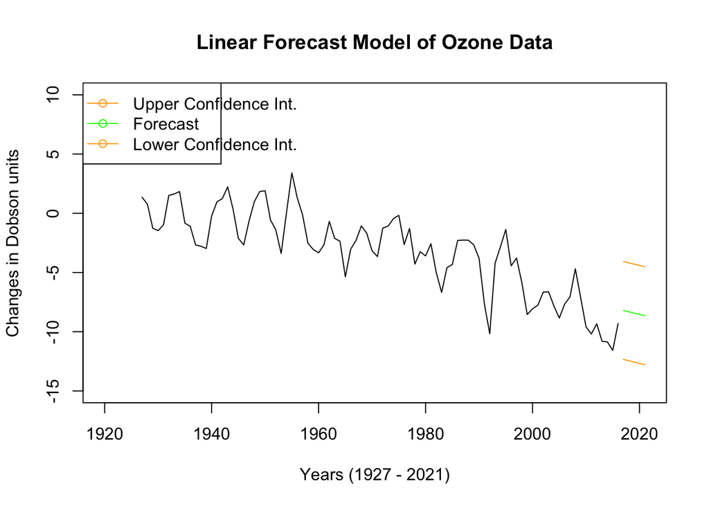

Figure 3.6: Linear Model Forecast

```r
plot(ozone_1927_2016, xlim = c(1920,2021), ylim = c(-15, 10), ylab = "Changes in Dobson units", main = "Linear Forecast Model of Ozone Data", xlab = "Years (1927 - 2021)")
lines(ts(as.vector(fcModel1[,1]), start = 2017), col="green", type="l")
lines(ts(as.vector(fcModel1[,2]), start = 2017), col="orange", type="l")
lines(ts(as.vector(fcModel1[,3]), start = 2017), col="orange", type="l")
legend("topleft", lty=1, pch=1, col=c("orange","green","orange"), text.width = 15, c("Upper Confidence Int.","Forecast", "Lower Confidence Int."))
```

## 3.5 3 ARIMA Analysis

The Ozone time series plot displays a downward trend. This means the time series is likely non-stationary and it will need to undergo differencing to make it stationary. This process will use ARIMA.

ARIMA(p,d,q)

-P is read from PACF plot (MA[p]) -Q is read from ACF plot (AR[q])

### 3.5.1 Testing for Changeing Variance

The time series graph does not show obvious changing variance, although variance can still be tested for using a box cox transformation and QQ plot. If there is any variance, it will need to be removed before any differencing procedures are applied.

The QQ plot below represents the original data set and not the residuals that were produced in previous sections.

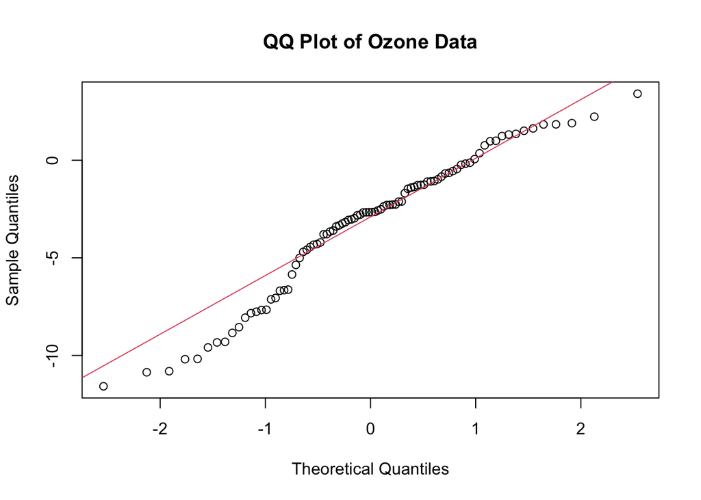

Figure 3.7: QQ Plot of time series

```r
# qq plot to assess normality
qqnorm(ozone_1927_2016, main = "QQ Plot of Ozone Data")
qqline(ozone_1927_2016, col = 2)
```

```r
shapiro.test(ozone_1927_2016)
```

```
##
##  Shapiro-Wilk normality test
##
## data:  ozone_1927_2016
## W = 0.95605, p-value = 0.004031
```

The QQ plot will help identify whether a time series plot has a normal distribution. If the dots move away from the red line, then it means there could be variance in the time series. The closer to the red line means less variance in the time series.

The original plot did not appear to have changing variance, although the QQ plot indicates there could be some variance by the diverging data points from the reference line. A box cox transformation may remove the variance if there is any.

```r
# Change negative values to positive (Shift the series)
BC = BoxCox.ar(ozone_1927_2016 + abs(min(ozone_1927_2016))+1, lambda = seq(0, 2, 0.1))
```

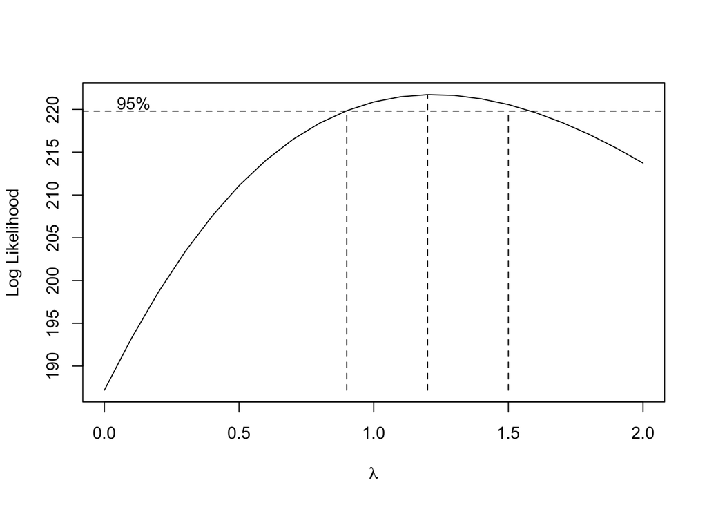

```r
# Obtain the lambda function
lambda <- BC$lambda[which(max(BC$loglike) == BC$loglike)]
print(paste0("The value of lambda is : ", lambda))
```

```
## [1] "The value of lambda is : 1.2"
```

For the box cox transformation, a lambda value of 1 is the same as using the original data. Therefore, if the confidence interval for the optimal lambda includes 1, then no transformation is needed. In this case, the value of lambda is 1.2, meaning that the plot will look similar to the original after transforming the data and we do not need to apply the transformations as there is only a small variance.

Lamba values: -1. is a reciprocal -.5 is a recriprocal square root 0.0 is a log transformation .5 is a square toot transform and 1.0 is no transform.

**Comparison of the original time series to the box cox transformed series:**

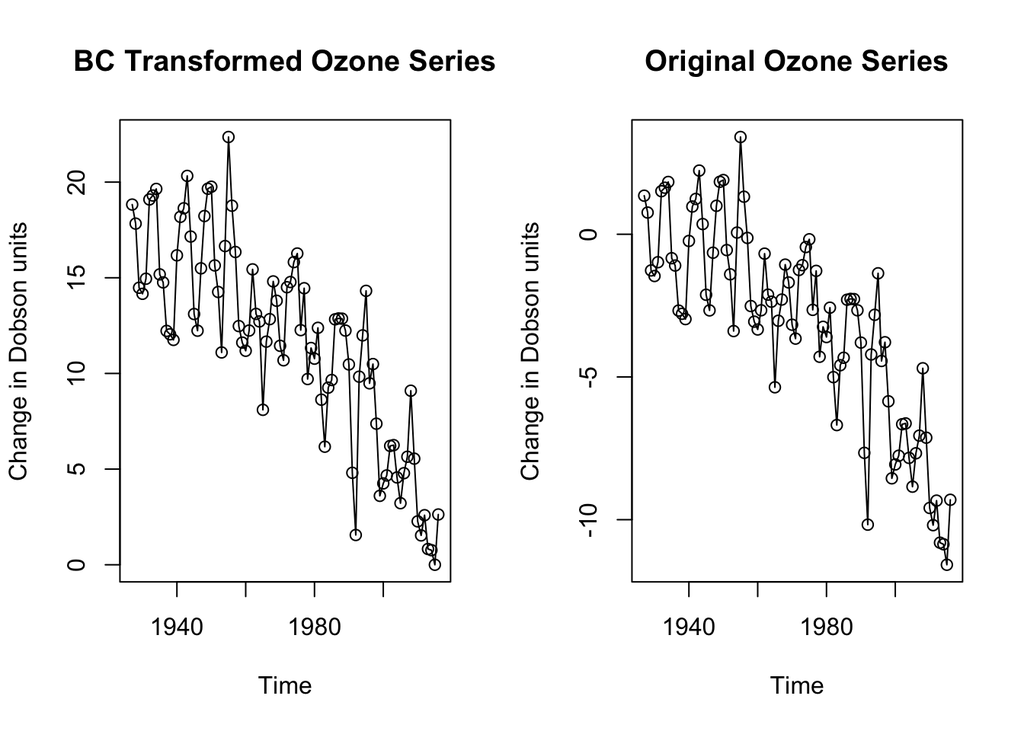

Figure 3.9: BC Plot of time series comparison

```r
# Compare the box cox transforamtion to the original series
par(mfrow=c(1,2))
ozone_1927_2016_shifted = ozone_1927_2016 + abs(min(ozone_1927_2016))+1
BC.ozone_1927_2016 = (ozone_1927_2016_shifted^lambda-1)/lambda

plot(BC.ozone_1927_2016,type='o',
     ylab='Change in Dobson units',
     main ="BC Transformed Ozone Series")

plot(ozone_1927_2016,
     type='o',
     ylab='Change in Dobson units',
     main ="Original Ozone Series")
```

```r
par(mfrow=c(1,1))
```

**Comparison of the original QQ plot to the box cox transformed QQ plot:**

```r
# Test the normality using qq plot. Compare it against the initial qq plot.

shapiro.test(BC.ozone_1927_2016)
```

```
##
##  Shapiro-Wilk normality test
##
## data:  BC.ozone_1927_2016
## W = 0.96644, p-value = 0.01995
```

```r
shapiro.test(ozone_1927_2016)
```

```
##
##  Shapiro-Wilk normality test
##
## data:  ozone_1927_2016
## W = 0.95605, p-value = 0.004031
```

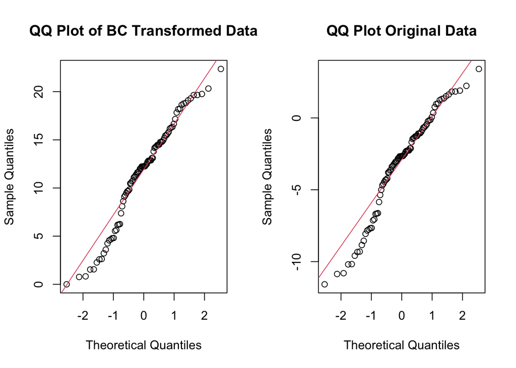

Figure 3.10: QQ Plot comparison

```r
par(mfrow=c(1,2))

qqnorm(BC.ozone_1927_2016, main = "QQ Plot of BC Transformed Data")
qqline(BC.ozone_1927_2016, col = 2)

qqnorm(ozone_1927_2016, main = "QQ Plot Original Data")
qqline(ozone_1927_2016, col = 2)
```

```r
par(mfrow=c(1,1))
```

Insights gained: - The shape of the transformed series is similar to the original - The original QQ plot looks similar to the box cox transformed QQ plot - Shapiro Wilk test show the original and transformed p-value as less than 0.05 - Lambda function is equal to 1.2,, meaning that a transformation is not necessary

For these reasons, a box cox transformation will not improve the results of the model as there is very little changing variance in the original time series. The final characteristic to test for is stationarity.

### 3.5.2 Testing for Stationarity

The time series plot shows a downward trend. We can use some tools to test the hypothesis (existence of a trend) such as ACF, Dicker-Fuller Unit Root Test and Phillips-Perron (PP) test. If the trend is stationary, an ARMA model can be used. If there is a trend, then a ARIMA model will be used.

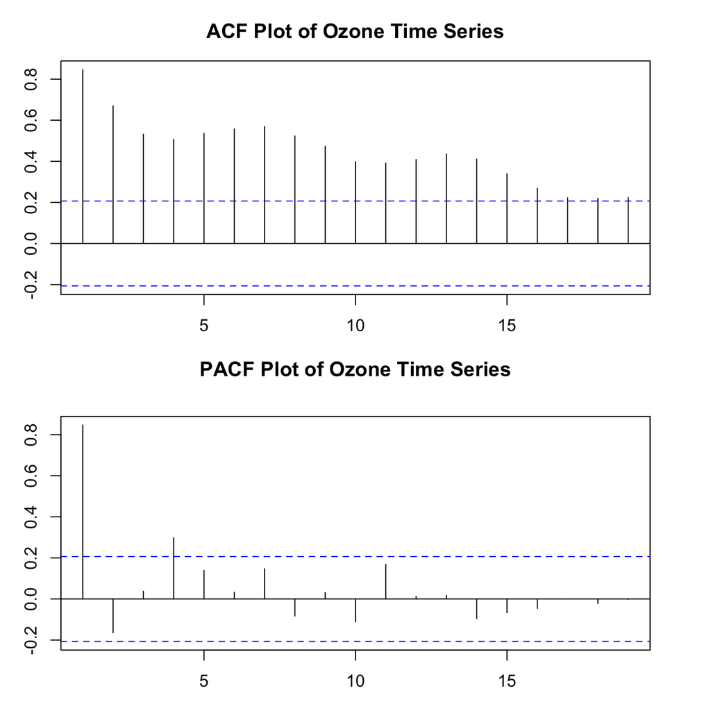

Figure 3.11: ACF and PACF analysis

```r
# ACf and PACF
par(mfrow=c(2,1),mar=c(3,3,3,3))
acf(ozone_1927_2016, main ="ACF Plot of Ozone Time Series")
pacf(ozone_1927_2016, main ="PACF Plot of Ozone Time Series")
```

```r
par(mfrow=c(1,1))

# Dicker Fuller unit root test
adf.test(ozone_1927_2016, alternative = c("stationary"))
```

```
##
##  Augmented Dickey-Fuller Test
##
## data:  ozone_1927_2016
## Dickey-Fuller = -3.2376, Lag order = 4, p-value = 0.0867
## alternative hypothesis: stationary
```

```r
adf.test(ozone_1927_2016, k=3,alternative = c("stationary"))
```

```
##
##  Augmented Dickey-Fuller Test
##
## data:  ozone_1927_2016
## Dickey-Fuller = -3.9376, Lag order = 3, p-value = 0.01596
## alternative hypothesis: stationary
```

```r
adf.test(ozone_1927_2016, k=5,alternative = c("stationary"))
```

```
##
##  Augmented Dickey-Fuller Test
##
## data:  ozone_1927_2016
## Dickey-Fuller = -2.5704, Lag order = 5, p-value = 0.3413
## alternative hypothesis: stationary
```

```r
# Phillips-Perron test
pp.test(ozone_1927_2016, alternative = c("stationary"))
```

```
##
##  Phillips-Perron Unit Root Test
##
## data:  ozone_1927_2016
## Dickey-Fuller Z(alpha) = -35.431, Truncation lag parameter = 3, p-value
## = 0.01
## alternative hypothesis: stationary
```

ACF: The ACF plot is displaying a decaying pattern, further highlighting that the time series has a trend and is non-stationary. The number of lags between each peak is the same, indicating there may be seasonality in the series.

Dicker Fuller test: At k = 4, the p-value = 0.0867 which is slightly above the limit of 0.05. Given the proximity to 0.05, the K lag order of 3 and 5 are tested as well, with k = 3 producing a p-value of 0.01596 and k = 5 producing a p-value of 0.3413. K = 3 is withing the p-value limits of stationarity.

### 3.5.3 3.3 Differencing (d)

**Difference the time series to remove the trend and analyse the ACF and PACF:**

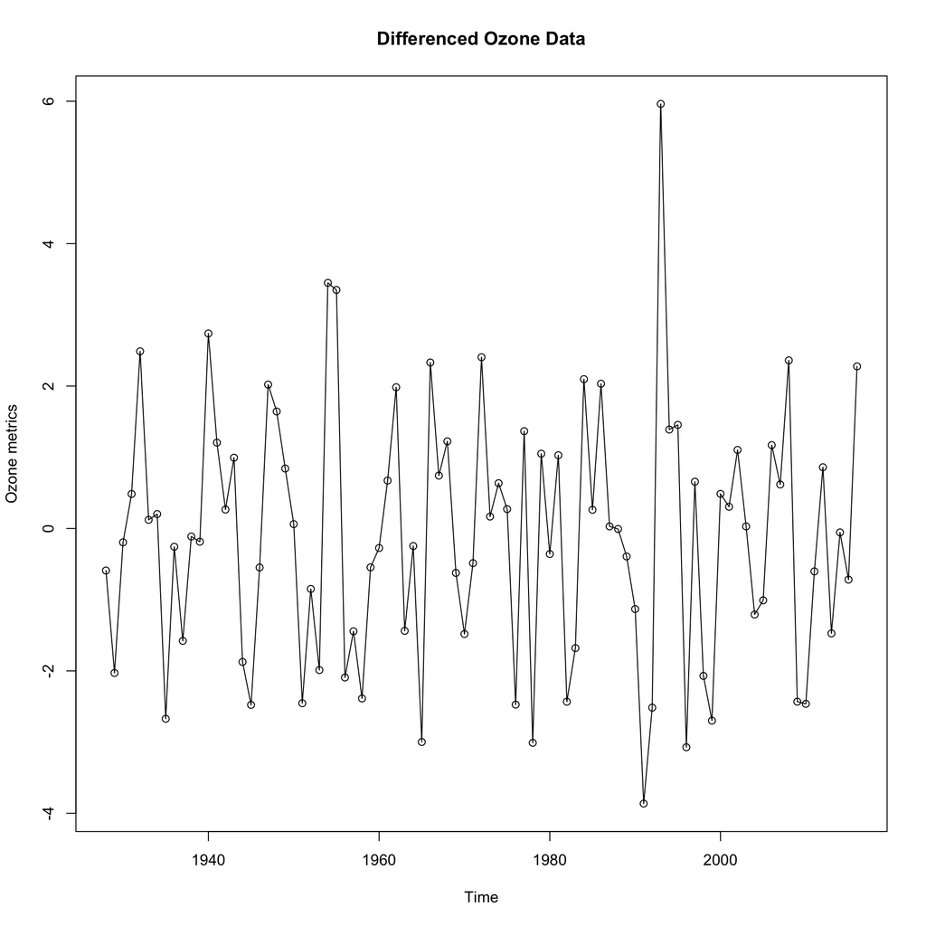

Figure 3.12: Differenced data set (d = 1)

```r
# Difference the data
diff.ozone_1927_2016 = diff(ozone_1927_2016,differences=1)
plot(diff.ozone_1927_2016,type='o',ylab='Ozone metrics', main ="Differenced Ozone Data")
```

```r
# test for stationarity
adf.test(diff.ozone_1927_2016, alternative = c("stationary"))
```

```
##
##  Augmented Dickey-Fuller Test
##
## data:  diff.ozone_1927_2016
## Dickey-Fuller = -7.1568, Lag order = 4, p-value = 0.01
## alternative hypothesis: stationary
```

```r
pp.test(diff.ozone_1927_2016, alternative = c("stationary"))
```

```
##
##  Phillips-Perron Unit Root Test
##
## data:  diff.ozone_1927_2016
## Dickey-Fuller Z(alpha) = -70.244, Truncation lag parameter = 3, p-value
## = 0.01
## alternative hypothesis: stationary
```

After differencing the time series once, the p-value of adf and pp test are less than 0.05. The time series is now stationary (d = 1).

### 3.5.4 AR and MA values

Multiple methods are used to find the optimal p and q values for the model such as ACF/PACF plots, EACF plot and BIC plot.

**Method 1: ACF / PACF**

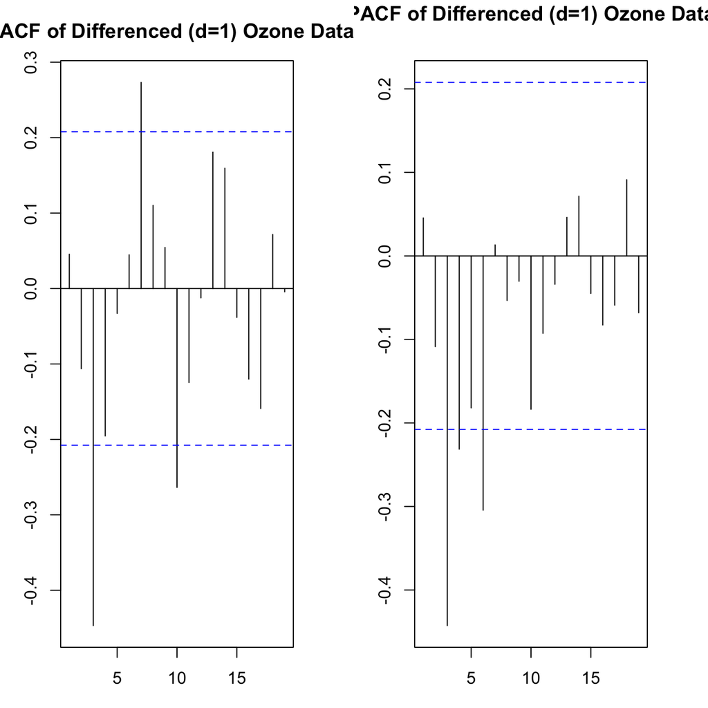

Figure 3.13: ACF and PACF analysis

```r
par(mfrow=c(1,2),mar=c(3,3,3,3))
acf(diff.ozone_1927_2016, main="ACF of Differenced (d=1) Ozone Data")
pacf(diff.ozone_1927_2016, main="PACF of Differenced (d=1) Ozone Data")
```

```r
par(mfrow=c(1,1))
```

ARIMA models using ACF/PACF:

ARIMA(p,d,q)

{ARIMA(1,1,1) ARIMA(1,1,2) ARIMA(2,1,1) ARIMA(2,1,2)}

**Method 2: EACF Plots**

```r
eacf(diff.ozone_1927_2016)
```

```
## AR/MA
##   0 1 2 3 4 5 6 7 8 9 10 11 12 13
## 0 o o x o o o x o o x o  o  o  o
## 1 x o x o o o o o o x o  o  o  o
## 2 x o x o o o x o o x o  o  o  o
## 3 x o x o o x o o o o o  o  o  o
## 4 x o o x o x o o o o o  o  o  o
## 5 x x x x o x o o o o o  o  o  o
## 6 o o o x x o o o o o o  o  o  o
## 7 o o o x o o o o o o o  o  o  o
```

The EACF plot displays values for q across the top and values for p on the vertical axis. The vertex occurs at position q = 3 and p = 0.

ARIMA models using EACF:

ARIMA(p,d,q)

{ARIMA(0,1,3) ARIMA(0,1,4) ARIMA(1,1,4)}

**Method 3: BIC Plots**

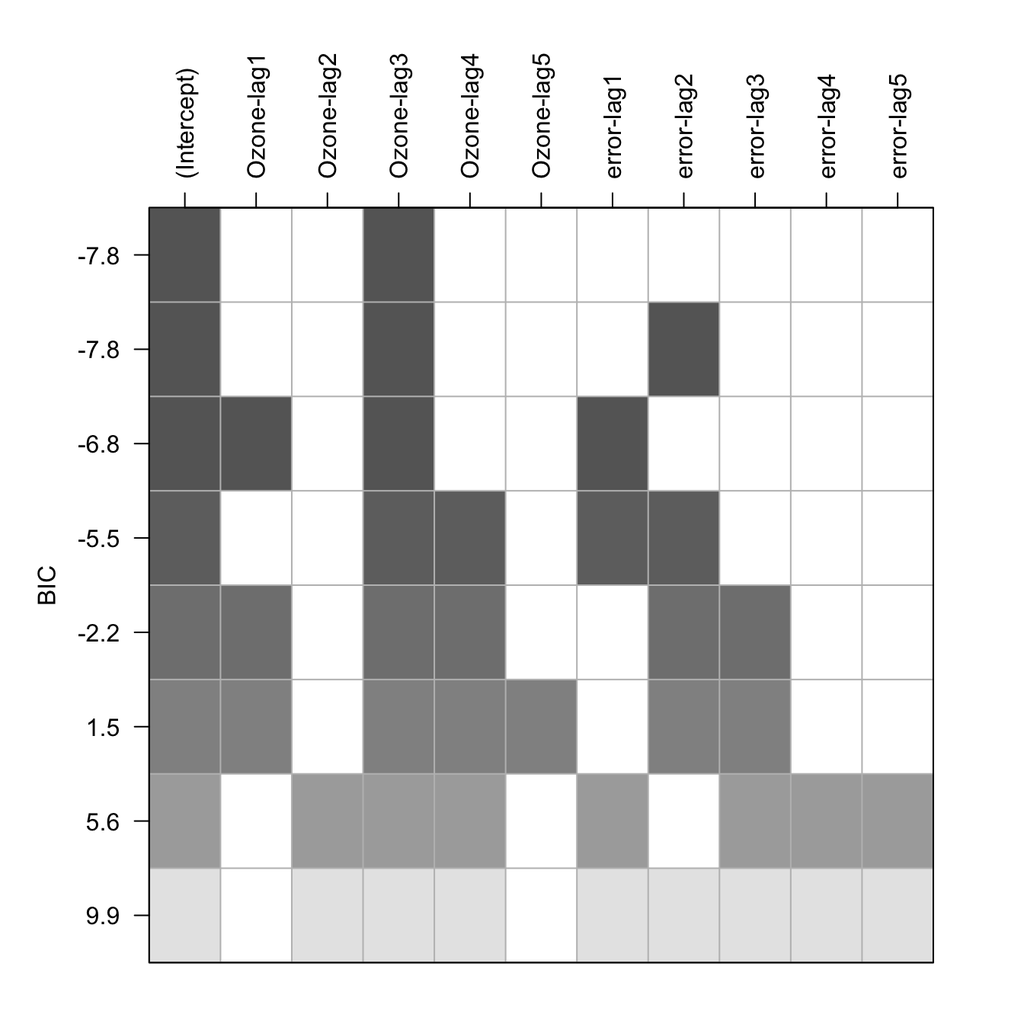

Figure 3.14: BIC analysis

```r
res = armasubsets(y=diff.ozone_1927_2016 , nar=5 , nma=5, y.name='Ozone', ar.method='ols')
plot(res)
```

p is only the left side and q is on the right side (denoted by ‘error’).

p value is equal to 3. q value is equal to 0 because there are no strong vertical bars or colors that reach the minimum BIC. Error-lag2 might be considered as slightly significant if the bar underneath it was more complete.

ARIMA models using BIC:

ARIMA(p,d,q)

{ARIMA(3,1,0)}

### 3.5.5 ARIMA Model Outcomes

There are a total of 8 ARIMA models derived from ACF/PACF, EACF, BIC methods:

{ARIMA(1,1,1) ARIMA(1,1,2) ARIMA(2,1,1) ARIMA(2,1,2) ARIMA(0,1,3) ARIMA(0,1,4) ARIMA(1,1,4) ARIMA(3,1,0)}

There is a tendency toward lower p values (1,2) and mid to high q values (3,4) for the this time series ARIMA model.

# 4 Conclusion

Time series models contain subjectivity in their approach. By using statistical tools and processes, it is possible to derive multiple time series models for a single data set. Within the scope of this investigation, a simple linear model is able to forecast the next 5 years of Ozone level changes in dobson units. ARIMA models are also useful, although require more work to remove variance, understand stationarity and finally to derive inputs for p and q that are likely to produce good forecasts.